# Rossmann探索性数据分析

### 4. 周日销量对比分析

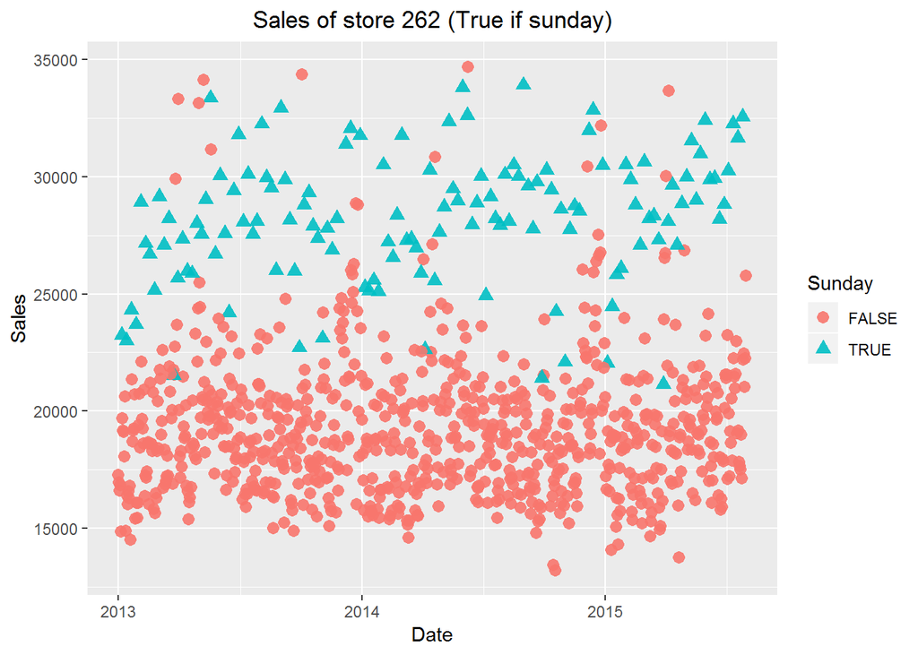

可以看出，对于少量周日开业的商店，销量会比平时更高，这可能也是这些店选择周日继续营业的原因，已经做过充分的盈亏调研。

### 5. 关键特征Heatmap

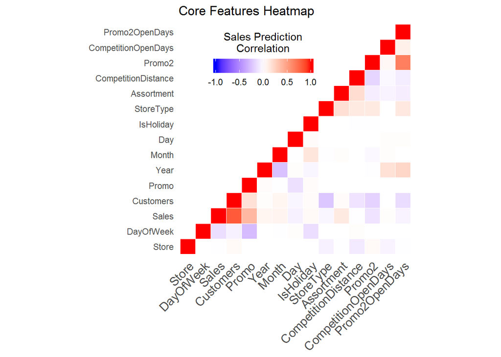

其实热力图分析存在一定的弊病，因为某些特征是因子变量，如果按照int来做相关性分析是最不合理的。如图中Store和Sales的相关性很弱，实际上从xgboost的特征重要性分析可以看出Store对销量的影响力是很大的。

# VI. 多变量分析

### 1. 探讨你在这部分探究中观察到的一些关系。通过观察感兴趣的特性，是否存在相互促进的特性？这些特性之间是否存在有趣或惊人的联系呢？

我探究了时间特征如月销量走势，周销量走势，商店类型StoreType和Assortment，周日销量特殊性分析，以及关键特征热力图分析。他们与目标销量特征，以及相互间都具有促进的作用。其中StoreType b和Assortment b，以及周日具有特殊性的规律存在，因此在特征工程和模型建模时，这一块需要额外处理。

### 2. 你是否创建过数据集的任何模型？讨论你模型的优缺点。

基于EDA分析，对于相关性较强和个体明显的特征做了详细的特征工程，然后创建了xgboost集成模型，最终在kaggle上取得了第12名的好成绩。  
优点：可以灵活处理各种类型的数据，包括连续值和离散值；在相对少的调参时间情况下，预测的准备率也可以比较高。；使用一些健壮的损失函数，对异常值的鲁棒性非常强。  
缺点：训练时间过长，不适合高维稀疏特征。

# VII. 定稿图与总结

### 1. 绘图一

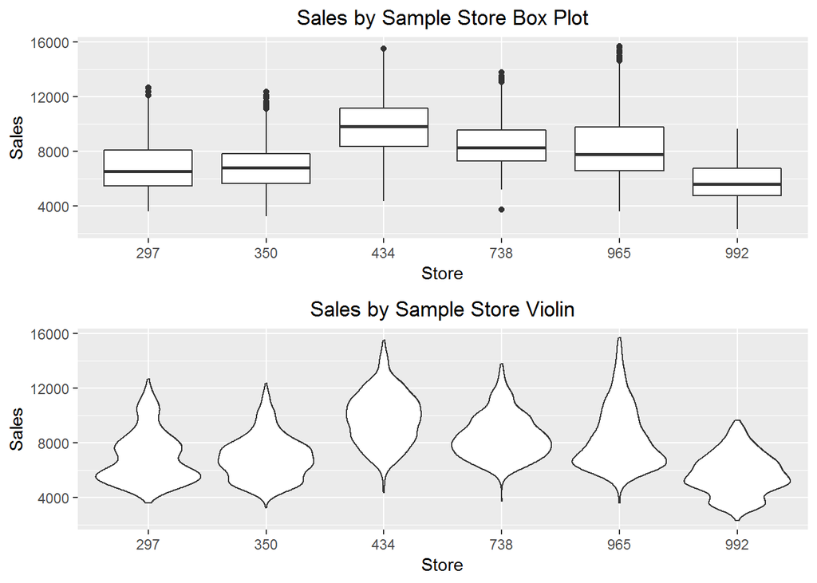

### 3. 绘图二

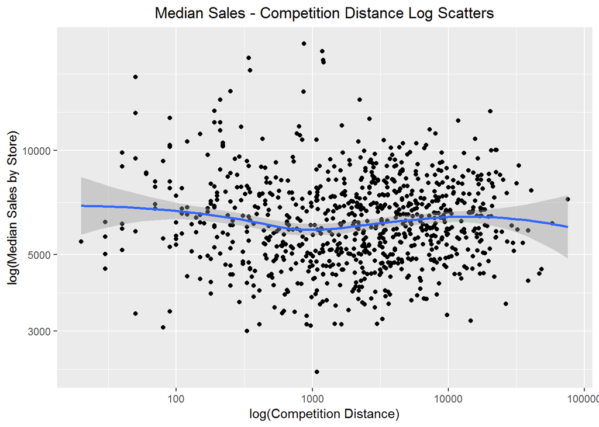

### 4. 描述二

竞争-销量分析：

- 竞争对手距离对于平均销量有较小的影响，当距离较小时平均销量最大，可以推测这是因为距离较小意味着一般是繁华的市区，导致附近的商店定价和销量比较高，或者可以理解成竞争压力导致的正面效应。
- 然后距离到10000的时间，平均销量也是比较高的，说明这是竞争最佳距离，太近了会导致竞争激烈，太远导致竞争压力过小。
- 从分布上讲，大部分的竞争对手距离分布在1000-10000之间。

### 5. 绘图三

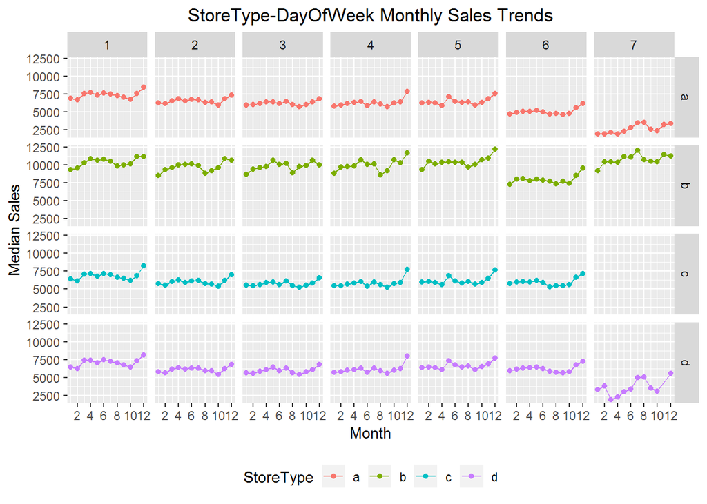

### 6. 描述三

# VIII. 反思

### 1. 在分析过程中遇到了什么困难？

对R语言不熟悉，所以对数据操作上遇到了不少困难，所以某些更高级的可视化分析无法去完成，然后对于grid.arrange中ggplot组合也不是很熟悉，本来想将多张图整合到一起，但在尺寸分割和共享图例上遇到了困难。

### 2. 在分析过程中取得了哪些成功？

这是Kaggle上的一个基于时间序列预测的项目，通过EDA分析，帮助发现特征中潜在的规律，并对于特征工程和模型建模起到了非常重要的作用。比如：

- 发现某些特征对销量的贡献度较小，无需再深入做特征工程，如节假日信息。
- 发现了某些重要特征，并在特征工程中，重点做这些特征间的聚合，如时间序列信息，顾客数的强相关性等。
- 发现了StoreType b和Assortment b，以及周日具有特殊性的规律存在，需要额外建模融合。

### 3. 将来工作中还可以通过哪些方式使分析更丰富（如：附加数据和分析）？

- 更高级的EDA分析，如多特征聚合分析，专门的时间序列分析工具等。
- 结合额外的数据集，如商店的天气和国家信息，以及google trends。
- EDA为特征工程提供了方向，产生新的工程特征后，继续做EDA分析，如此循环往复。